# Characterizing Negative Affect in Adolescence

Katherine Grisanzio

## Motivation

Research shows negative affect increases in healthy adolescents, and this normative change is paralleled by increasing risk for the onset of psychopathology. However, research is limited in characterizing qualitative differences in the type of negative affect experienced beyond the positive-negative valence dimension. In this analysis, we establish the relationship between different forms of negative affect and functioning outcomes (i.e., different facets of social functioning and life satisfaction), and examine whether these forms of negative affect are differentially prevalent across late childhood and adolescence.

## Dataset

Data was collected as a part of the Human Connectome Project in Development, a large multi-site study aiming to characterize changes in brain development. 770 participants aged 8-17 years completed self-report measures that assessed a wide range of negative affective experiences. Variables in the dataset are in the form of 4 or 5-point Likert responses.

## Primary Analysis Aims

### - Exploratory Factor Analysis

The first aim of the study was to uncover the latent structure of the negative affect variables to obtain meaningful summary scores for different forms of negative affect in our sample. We implemented a data-driven approach to identify forms of negative affect.

### - Confirmatory Factor Analysis

To evaluate the fit of the factor structure extracted in the EFA, we conducted a confirmatory factor analysis (CFA). We calculated and report the standard measures and fit rules to assess how well the proposed model produced by the EFA captures the covariance between the measured items.

### - Generalized Additive Modeling

To explore non-linear age-related changes, we used generalized additive models (GAM) with thin-plate regression splines. This method produces regression equations that fit the data using cross-validation procedures but are also penalized for the number of parameters to prevent overfitting.

## Load Packages

```r
if (!require("dplyr")) {install.packages("dplyr"); require("dplyr")}
if (!require("psych")) {install.packages("psych"); require("psych")}
if (!require("plyr")) {install.packages("plyr"); require("plyr")}
if (!require("Hmisc")) {install.packages("Hmisc"); require("Hmisc")}
if (!require("corrplot")) {install.packages("corrplot"); require("corrplot")}
if (!require("mgcv")) {install.packages("mgcv"); require("mgcv")}
if (!require("viridis")) {install.packages("viridis"); require("viridis")}
if (!require("lavaan")) {install.packages("lavaan"); require("lavaan")}
if (!require("visreg")) {install.packages("visreg"); require("visreg")}
if (!require("data.table")) {install.packages("data.table"); require("data.table")}
if (!require("igraph")) {install.packages("igraph"); require("igraph")}
if (!require("ggplot2")) {install.packages("ggplot2"); require("ggplot2")}
if (!require("car")) {install.packages("car"); require("car")}
if (!require("knitr")) {install.packages("knitr"); require("knitr")}
if (!require("equaltestMI")) {install.packages("equaltestMI"); require("equaltestMI")}
if (!require("ggpubr")) {install.packages("ggpubr"); require("ggpubr")}
```

## Import Data

```r
# Set working directory
setwd("/Users/katherinegrisanzio/Dropbox/Harvard/Lab/Second Year Project - HCP/NIH Toolbox Emotion Data/")

# Load data
data_raw_old <- read.csv("20190424_Clean_ToolboxRaw_EmotionDataset.csv")
data_scored_old <- read.csv("20190424_Clean_ToolboxScored_EmotionDataset.csv")
data_demo_old <- read.csv("Combined_basic_demographics.csv")
data_child_eatq_bisbas_old <- read.csv("HCPDChild_DATA_2019-08-13_1734.csv")
data_parent_cbcl_eatq_bisbas_old <- read.csv("HCPDParent_DATA_2019-08-13-1733.csv")
data_raw_new <- read.csv("April2019throughMar2020_KG Data_HCD_Toolbox Emotion_Raw.csv")
data_child_eatq_bisbas_new <- read.csv("April2019throughMar2020_KG Data_HCPDChild_REDCap.csv")
new_redcap <- read.csv("REDCap_hcpdchild_05_14_2021.csv")
```

## Process Data

```r
# Clean and select relevant columns from each dataset

# data_raw
relevant_vars_data_raw <- c("PIN", "Inst", "ItemID", "Response")
data_raw_old <- data_raw_old[relevant_vars_data_raw] # select relevant cols from both old and new dataset
data_raw_new <- data_raw_new[relevant_vars_data_raw]
data_raw_new$PIN <- gsub("_V1", "", data_raw_new$PIN) # Remove _V1 from ID column for merging
data_raw <- rbind(data_raw_old, data_raw_new) # combine old and new datasets
data_raw <- distinct(data_raw) # remove duplicate rows

# Set 'ItemID' as factor
data_raw$ItemID <- as.factor(data_raw$ItemID)

# Rename items that are the same across child and adult questionnaires - name it "childsurveyname_adultsurveyname"
levels(data_raw$ItemID)[levels(data_raw$ItemID)=="PedRepDep36"] <- "PedRepDep36_Depression48"
levels(data_raw$ItemID)[levels(data_raw$ItemID)=="Depression48"] <- "PedRepDep36_Depression48"

levels(data_raw$ItemID)[levels(data_raw$ItemID)=="PedRepDep37"] <- "PedRepDep37_Depression43"
levels(data_raw$ItemID)[levels(data_raw$ItemID)=="Depression43"] <- "PedRepDep37_Depression43"

levels(data_raw$ItemID)[levels(data_raw$ItemID)=="PedRepDep38"] <- "PedRepDep38_Depression36"
levels(data_raw$ItemID)[levels(data_raw$ItemID)=="Depression36"] <- "PedRepDep38_Depression36"

levels(data_raw$ItemID)[levels(data_raw$ItemID)=="PedRepAnx44"] <- "PedRepAnx44_Anxiety51"
levels(data_raw$ItemID)[levels(data_raw$ItemID)=="Anxiety51"] <- "PedRepAnx44_Anxiety51"

levels(data_raw$ItemID)[levels(data_raw$ItemID)=="PedRepAnx48"] <- "PedRepAnx48_Anxiety57"
levels(data_raw$ItemID)[levels(data_raw$ItemID)=="Anxiety57"] <- "PedRepAnx48_Anxiety57"

# Remove parent-reported and adult (18+) data
data_raw <- data_raw[!grepl("pxy|prox", ignore.case=TRUE, data_raw$ItemID),]
data_raw <- data_raw[!grepl("18+", ignore.case=TRUE, data_raw$Inst),]

# Remove 'Inst' variable
data_raw$Inst <- NULL

# Remove -1's from Response variable and replace with NA
data_raw$Response[data_raw$Response < 0] <- NA

# Reshape to wide
data_raw_wide <- reshape(data_raw, idvar = c("PIN"), timevar = "ItemID", direction = "wide")


# data_demo
names(data_demo_old)[1] <- "PIN" # rename all ID variables "PIN" for merging
relevant_vars_demo <- c("PIN", "gender", "age")
data_demo_old <- data_demo_old[relevant_vars_demo]

names(data_child_eatq_bisbas_new)[2] <- "PIN" # rename all ID variables "PIN" for merging
data_demo_new <- data_child_eatq_bisbas_new[relevant_vars_demo]

data_demo <- rbind(data_demo_old, data_demo_new)


# bis
names(data_child_eatq_bisbas_old)[3] <- "PIN"
data_child_eatq_bisbas_old <- data_child_eatq_bisbas_old[, c(3, 76:95)]
data_child_eatq_bisbas_new <- data_child_eatq_bisbas_new[, c(2, 8:27)]
names(new_redcap)[2] <- "PIN"
new_redcap <- new_redcap[which(new_redcap$visit == 1), ]
new_redcap <- new_redcap[, c(2, 342:361)]
new_redcap <- new_redcap[, c(1, 2, 13, 15:21, 3:12, 14)]
bisbas_data <- rbind(data_child_eatq_bisbas_old, data_child_eatq_bisbas_new, new_redcap)
bisbas_data <- bisbas_data[rowSums(is.na(bisbas_data[,2:21]))!=20,] # remove rows with all NA
bisbas_data <- distinct(bisbas_data) # remove duplicates from merging

# Merge datasets

# Merge data_scored and data_demo
merge_temp1 <- base::merge(data_demo, data_raw_wide, by=c("PIN"), all=TRUE)

# Merge merge_temp1 and data_child_eatq_bisbas
data <- base::merge(merge_temp1, bisbas_data, by=c("PIN"), all=TRUE)

# Only keep participants > age 8
data <- data[ which(data$age >= 8),]

# Add a truncated age variable for plotting
data$age_trunc <- trunc(data$age)

# Remove duplicates caused by merging
data_data <- distinct(data)

# Retain variables that relate to core negative affect
core_emo_vars <- c("PIN", "age", "gender", "age_trunc",
                   "Response.PedRepAng13", "Response.PedRepAng14", "Response.PedRepAng16", "Response.PedRepAng17", "Response.PedRepAng18",
                   "Response.PedRepAnx42", "Response.PedRepAnx43", "Response.PedRepAnx44_Anxiety51", "Response.PedRepAnx46", "Response.PedRepAnx48_Anxiety57", "Response.PedRepAnx50", "Response.PedRepAnx51",
                   "Response.PedRepDep36_Depression48", "Response.PedRepDep38_Depression36", "Response.PedRepDep41",
                   "bisbas1", "bisbas2", "bisbas3", "bisbas4", "bisbas5", "bisbas6", "bisbas7")

data <- data_data[core_emo_vars] # data for primary factor analysis

# Remove columns that have the same values for all participants, as these have 0 variance
data <- data[vapply(data, function(x) length(unique(x)) > 1, logical(1L))]


# Limit age
efa_data_primary <- data[ which(data$age >= 8 & data$age < 18),]

# View number of NA's for each person, sorted
# sort(rowSums(is.na(efa_data_primary)))

# View items with most missing data
# sort(colSums(is.na(efa_data_primary))/nrow(efa_data_primary))

# Remove participants with more than 20% missing data
efa_data_primary <- efa_data_primary[rowSums(is.na(efa_data_primary))/ncol(efa_data_primary) <= .20,]

# To keep ordinal structure of the Likert data, median replace the remaining NAs
for(j in 5:ncol(efa_data_primary)) {
  m <- median(efa_data_primary[,j], na.rm=TRUE)

  for (i in 1:nrow(efa_data_primary)) {
    if(is.na(efa_data_primary[i,j])) {efa_data_primary[i,j] <- m}
  }
}

# Remove now empty levels for PIN
efa_data_primary$PIN <- as.character(efa_data_primary$PIN)
efa_data_primary$PIN <- as.factor(efa_data_primary$PIN)

efa_data_primary$gender <- as.factor(efa_data_primary$gender) # and factor gender

# Re-name var names for interpretation
efa_data_primary <- efa_data_primary %>%
  dplyr::rename(
    Response.PedRepAng13_I_felt_mad = Response.PedRepAng13,
    Response.PedRepAng14_I_was_so_angry_I_felt_like_yelling_at_somebody = Response.PedRepAng14,
    Response.PedRepAng16_I_felt_fed_up = Response.PedRepAng16,
    Response.PedRepAng17_I_was_so_angry_I_felt_like_throwing_something = Response.PedRepAng17,
    Response.PedRepAng18_I_felt_upset = Response.PedRepAng18,
    Response.PedRepAnx42_I_felt_scared = Response.PedRepAnx42,
    Response.PedRepAnx43_I_worried_about_what_could_happen_to_me = Response.PedRepAnx43,
    Response.PedRepAnx46_I_worried_when_I_went_to_bed_at_night = Response.PedRepAnx46,
    Response.PedRepAnx50_I_worried_when_I_was_at_home = Response.PedRepAnx50,
    Response.PedRepAnx51_I_got_scared_really_easily = Response.PedRepAnx51,
    Response.PedRepAnx44_Anxiety51_I_felt_worried = Response.PedRepAnx44_Anxiety51,
    Response.PedRepDep41_I_could_not_stop_feeling_sad = Response.PedRepDep41,
    bisbas1_I_usually_get_very_tense_when_I_think_something_unpleasant_is_going_to_happen = bisbas1,
    bisbas2_I_worry_about_making_mistakes = bisbas2,
    bisbas3_I_am_hurt_when_people_scold_me_or_tell_me_that_I_do_something_wrong = bisbas3,
    bisbas4_I_feel_pretty_upset_when_I_think_that_someone_is_angry_with_me = bisbas4,
    bisbas5_I_do_not_become_fearful_or_nervous_even_when_something_bad_happens_to_me = bisbas5,
    bisbas6_I_feel_worried_when_I_think_I_have_done_poorly_at_something = bisbas6,
    bisbas7_I_am_very_fearful_compared_to_my_friends = bisbas7,
    Response.PedRepAnx48_Anxiety57_I_felt_nervous = Response.PedRepAnx48_Anxiety57,
    Response.PedRepDep36_Depression48_I_felt_unhappy = Response.PedRepDep36_Depression48,
    Response.PedRepDep38_Depression36_I_felt_sad = Response.PedRepDep38_Depression36)
```

## Exploratory Factor Analysis

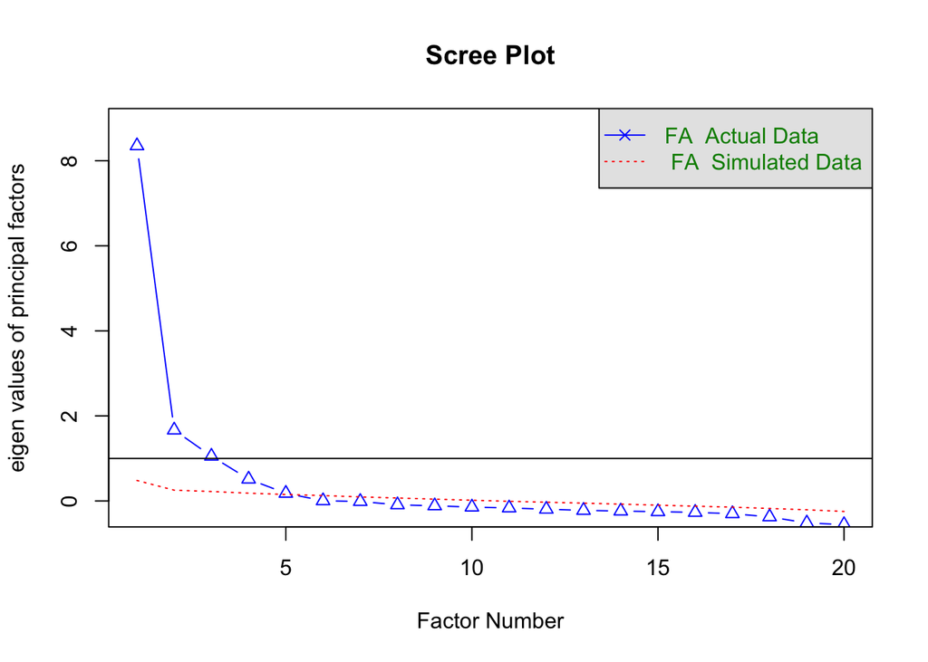

```
## Parallel analysis suggests that the number of factors =  5  and the number of components =  NA
```

```r
# Calculate polychoric correlations for ordinal data
cor_mat_smooth <- polychoric(efa_data_primary[,c(5:23, 25)], smooth = TRUE)

# Determine number of factors - scree plot and parallel analysis
var <- polychoric(efa_data_primary[,c(5:23, 25)], smooth = TRUE)$rho
## Parallel analysis compares the eigenvalues from the data to eigenvalues generated from a random
## dataset and retains factors whose eigenvalues > eigenvalues from random data
fa.parallel(var, fm="ml", fa="fa", n.obs = 770, main = "Scree Plot")
```

```r
# Run factor analysis
fac_solution <- fa(efa_data_primary[,c(5:23, 25)], nfactors = 4,  rotate="oblimin", scores=TRUE, fm = "ml", cor = "poly")
# View loadings
# print(fac_solution$loadings, cutoff = 0.3, sort = TRUE)

# Calculate variance explained
SS<-colSums(fac_solution$Structure^2)
# Compute percentage of explained variance by factor
SS/length(fac_solution$communality)
```

```
##       ML1       ML2       ML4       ML3
## 0.3521817 0.2826216 0.1833740 0.2989888
```

```r
# Total explained variability
mean(fac_solution$communality)
```

```
## [1] 0.6255376
```

```r
# Add factor scores to dataframe
df_to_merge <- data.frame(fac_solution$scores)
efa_data_primary <- cbind(efa_data_primary, df_to_merge)

#names(efa_data_primary)[34] <- "General_Worry"
#names(efa_data_primary)[35] <- "Anger"
#names(efa_data_primary)[36] <- "Sadness"
#names(efa_data_primary)[37] <- "Evaluative_Worry"
```

## Confirmatory Factor Analysis

```r
# Abbreviated variable names
efa_data_primary_cfa <- efa_data_primary %>%
  dplyr::rename(
    Response.PedRepAng13 = Response.PedRepAng13_I_felt_mad,
    Response.PedRepAng14 = Response.PedRepAng14_I_was_so_angry_I_felt_like_yelling_at_somebody,
    Response.PedRepAng16 = Response.PedRepAng16_I_felt_fed_up,
    Response.PedRepAng17 = Response.PedRepAng17_I_was_so_angry_I_felt_like_throwing_something,
    Response.PedRepAng18 = Response.PedRepAng18_I_felt_upset,
    Response.PedRepAnx42 = Response.PedRepAnx42_I_felt_scared,
    Response.PedRepAnx43 = Response.PedRepAnx43_I_worried_about_what_could_happen_to_me,
    Response.PedRepAnx46 = Response.PedRepAnx46_I_worried_when_I_went_to_bed_at_night,
    Response.PedRepAnx48_Anxiety57 =  Response.PedRepAnx48_Anxiety57_I_felt_nervous,
    Response.PedRepAnx50 = Response.PedRepAnx50_I_worried_when_I_was_at_home,
    Response.PedRepAnx51 = Response.PedRepAnx51_I_got_scared_really_easily,
    Response.PedRepAnx44_Anxiety51 = Response.PedRepAnx44_Anxiety51_I_felt_worried,
    Response.PedRepDep41 = Response.PedRepDep41_I_could_not_stop_feeling_sad,
    Response.PedRepDep36_Depression48 = Response.PedRepDep36_Depression48_I_felt_unhappy,
    Response.PedRepDep38_Depression36 = Response.PedRepDep38_Depression36_I_felt_sad,
    bisbas1 = bisbas1_I_usually_get_very_tense_when_I_think_something_unpleasant_is_going_to_happen,
    bisbas2 = bisbas2_I_worry_about_making_mistakes,
    bisbas3 = bisbas3_I_am_hurt_when_people_scold_me_or_tell_me_that_I_do_something_wrong,
    bisbas4 = bisbas4_I_feel_pretty_upset_when_I_think_that_someone_is_angry_with_me,
    bisbas6 = bisbas6_I_feel_worried_when_I_think_I_have_done_poorly_at_something)

# Set CFA model
Rmot2 <- na.omit(efa_data_primary_cfa[,c(5:23, 25)])
mot_model2 <- '
worry =~ Response.PedRepAnx42 + Response.PedRepAnx43 + Response.PedRepAnx44_Anxiety51 + Response.PedRepAnx46 + Response.PedRepAnx48_Anxiety57 + Response.PedRepAnx50 + Response.PedRepAnx51
anger =~ Response.PedRepAng13 + Response.PedRepAng14 + Response.PedRepAng16 + Response.PedRepAng17
sadness =~ Response.PedRepAng18 + Response.PedRepDep36_Depression48 + Response.PedRepDep38_Depression36 + Response.PedRepDep41
eval_antic =~ bisbas1 + bisbas2 + bisbas3 + bisbas6 + bisbas4'

# Fit CFA models
fit1 <- lavaan::cfa(mot_model2, data = efa_data_primary_cfa,
                       ordered = names(Rmot2), meanstructure = TRUE)

# Model 2: configural invariance. The same factor structure is imposed on all groups.
fit2 <- lavaan::cfa(mot_model2, data = efa_data_primary_cfa,
                    ordered = names(Rmot2), meanstructure = TRUE, group = "gender")

# Model 3: weak invariance. The factor loadings are constrained to be equal across groups.
fit3 <- lavaan::cfa(mot_model2, data = efa_data_primary_cfa,
                    ordered = names(Rmot2), meanstructure = TRUE, group = "gender", group.equal = "loadings")

# Model 4: strong invariance. The factor loadings and intercepts are constrained to be equal across groups.
fit4 <- lavaan::cfa(mot_model2, data = efa_data_primary_cfa,
                    ordered = names(Rmot2), meanstructure = TRUE, group = "gender", group.equal = c("intercepts", "loadings"))


# Model comparison tests
lavTestLRT(fit2, fit3, fit4)
```

```
## Scaled Chi-Squared Difference Test (method = "satorra.2000")
##
## lavaan NOTE:
##     The "Chisq" column contains standard test statistics, not the
##     robust test that should be reported per model. A robust difference
##     test is a function of two standard (not robust) statistics.
##
##       Df AIC BIC  Chisq Chisq diff Df diff Pr(>Chisq)
## fit2 328         669.79
## fit3 344         728.76     25.747      16    0.05769 .
## fit4 395         763.95     60.928      51    0.16092
## ---
## Signif. codes:  0 '***' 0.001 '**' 0.01 '*' 0.05 '.' 0.1 ' ' 1
```

```r
# Produces two tests: the first test compares the first model versus the second model, while the second test compares the second model versus the third model.
# Because both p-values are non-significant, we can conclude that both weak and strong invariance
# is supported in the data, meaning we are able to compare the values of the latent means across the
# two groups.
```

## Factor Loading Plot

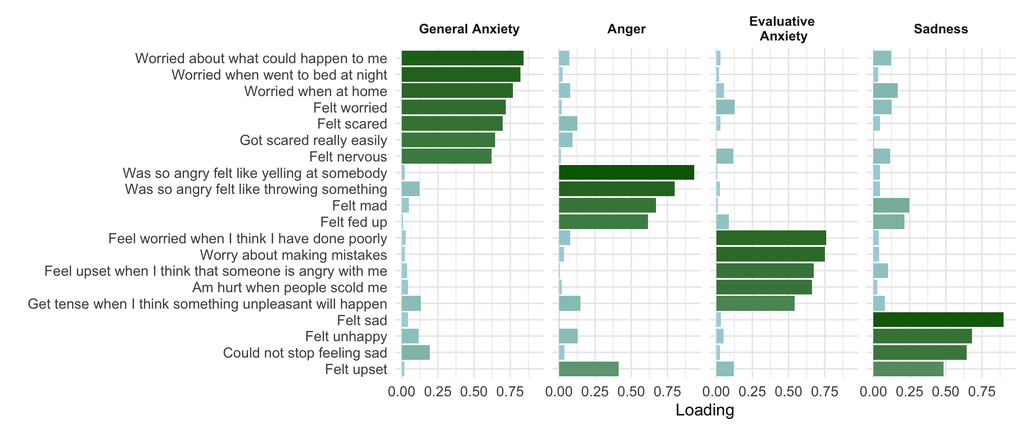

```r
# Convert loading list to a dataframe
loadings_sorted <- fa.sort(fac_solution$loadings)
loadings_df <- data.frame(matrix(as.numeric(loadings_sorted), attributes(loadings_sorted)$dim, dimnames=attributes(loadings_sorted)$dimnames))

# Make long for plotting
loadings_df <- data.frame(item=rownames(loadings_df), loadings_df, row.names=NULL) # get ID as variable rather than row name
loadings_df$item <- factor(loadings_df$item, levels = loadings_df$item) # lock in factor level order for plot to be sorted
varying <- colnames(loadings_df)[2:5]
loadings_df_long <- reshape(loadings_df, varying = varying, idvar = "item", timevar = "factor", v.names = "loading", times = varying, direction = "long")
loadings_df_long$factor <- factor(loadings_df_long$factor, levels = c("ML1", "ML2", "ML4", "ML3"), labels = c("General Anxiety", "Anger", "Evaluative \nAnxiety", "Sadness")) # re-order factors for plotting


# Re-name item names to be more succinct
loadings_df_long$item <- revalue(loadings_df_long$item, c(
  "Response.PedRepAnx46_I_worried_when_I_went_to_bed_at_night"="Worried when went to bed at night",
  "Response.PedRepAnx43_I_worried_about_what_could_happen_to_me"="Worried about what could happen to me",
  "Response.PedRepAnx50_I_worried_when_I_was_at_home" = "Worried when at home",
  "Response.PedRepAnx42_I_felt_scared" = "Felt scared",
  "Response.PedRepAnx44_Anxiety51_I_felt_worried" = "Felt worried",
  "Response.PedRepAnx51_I_got_scared_really_easily" = "Got scared really easily",
  "Response.PedRepDep41_I_could_not_stop_feeling_sad" = "Could not stop feeling sad",
  "Response.PedRepAng14_I_was_so_angry_I_felt_like_yelling_at_somebody" = "Was so angry felt like yelling at somebody",
  "Response.PedRepAng13_I_felt_mad" = "Felt mad",
  "Response.PedRepAng17_I_was_so_angry_I_felt_like_throwing_something" = "Was so angry felt like throwing something",
  "Response.PedRepAng16_I_felt_fed_up" = "Felt fed up",
  "Response.PedRepAng18_I_felt_upset" = "Felt upset",
  "bisbas2_I_worry_about_making_mistakes" = "Worry about making mistakes",
  "bisbas6_I_feel_worried_when_I_think_I_have_done_poorly_at_something" = "Feel worried when I think I have done poorly",
  "bisbas1_I_usually_get_very_tense_when_I_think_something_unpleasant_is_going_to_happen" = "Get tense when I think something unpleasant will happen",
  "bisbas3_I_am_hurt_when_people_scold_me_or_tell_me_that_I_do_something_wrong" = "Am hurt when people scold me",
  "bisbas4_I_feel_pretty_upset_when_I_think_that_someone_is_angry_with_me" = "Feel upset when I think that someone is angry with me",
  "Response.PedRepAnx48_Anxiety57_I_felt_nervous" = "Felt nervous",
  "Response.PedRepDep38_Depression36_I_felt_sad" = "Felt sad",
  "Response.PedRepDep36_Depression48_I_felt_unhappy" = "Felt unhappy"
))

# Plot
efaplot <- ggplot(loadings_df_long, aes(item, abs(loading), fill=abs(loading))) +
  facet_wrap(~ factor, nrow=1) +
  geom_bar(stat = "identity") +
  coord_flip() +
  scale_x_discrete(limits = rev(levels(loadings_df_long$item))) +
  scale_fill_gradient2(name = "Loading",
                       high = "darkgreen", mid = "lightblue", low = "navyblue",
                       midpoint = 0, guide = "none") +
  ylab("Loading") +
  theme_minimal(base_size=14) +
  xlab("") +
  theme(axis.text.x = element_text(size = 12), axis.text.y = element_text(size = 12), strip.text.x = element_text(face="bold"))
efaplot
```